# Gene set enrichment analysis - RNA-seq

CCDL for ALSF

November 2020

# 1 Purpose of this analysis

This example is one of pathway analysis module set, we recommend looking at the pathway analysis table below to help you determine which pathway analysis method is best suited for your purposes.

**IDENTICAL TO MICROARRAY EXAMPLE**

This particular example analysis shows how you can use gene set enrichment analysis (GSEA) to detect situations where all genes in a predefined gene set change in a coordinated way, detecting even small statistical but coordinated changes between two biological states. Genes are ranked from most highly positive to most highly negative, weighted according to their gene-level statistic, which is essential to the calculation of the enrichment score (ES), a pathway-level statistic, for each gene set. More specifically, an ES is calculated by starting with the most highly ranked genes (based on the gene-level statistic selected for ranking) and increasing the score when a gene is in the pathway and decreasing the score when a gene is not in the pathway. Normalized enrichment scores (NES) are enrichment scores that are scaled to account for gene sets of different sizes (Korotkevich *et al.* 2019; Subramanian *et al.* 2005).

⬇️ **Jump to the analysis code** ⬇️

**IDENTICAL TO OTHER PATHWAY ANALYSIS EXAMPLES**

### 1.0.1 What is pathway analysis?

Pathway analysis refers to any one of many techniques that uses predetermined sets of genes that are related or coordinated in their expression in some way (e.g., participate in the same molecular process, are regulated by the same transcription factor) to interpret a high-throughput experiment. In the context of [refine.bio](https://www.refine.bio/), we use these techniques to analyze and interpret genome-wide gene expression experiments. The rationale for performing pathway analysis is that looking at the pathway-level may be more biologically meaningful than considering individual genes, especially if a large number of genes are differentially expressed between conditions of interest. In addition, many relatively small changes in the expression values of genes in the same pathway could lead to a phenotypic outcome and these small changes may go undetected in differential gene expression analysis.

We highly recommend taking a look at [Ten Years of Pathway Analysis: Current Approaches and Outstanding Challenges](https://journals.plos.org/ploscompbiol/article?id=10.1371/journal.pcbi.1002375) from Khatri *et al.* (2012) for a more comprehensive overview. We have provided primary publications and documentation of the methods we will introduce below as well as some recommended reading in the `Resources for further learning` section.

### 1.0.2 How to choose a pathway analysis?

This table summarizes the pathway analyses examples in this module.

| Analysis | What is required for input | What output looks like | ✅ Pros | ⚠️ Cons |
| --- | --- | --- | --- | --- |
| [**ORA (Over-representation Analysis)**](https://alexslemonade.github.io/refinebio-examples/03-rnaseq/pathway-analysis_rnaseq_01_ora.html) | A list of gene IDs (no stats needed) | A per-pathway hypergeometric test result | - Simple - Inexpensive computationally to calculate p-values | - Requires arbitrary thresholds and ignores any statistics associated with a gene - Assumes independence of genes and pathways |
| [**GSEA (Gene Set Enrichment Analysis)**](https://alexslemonade.github.io/refinebio-examples/03-rnaseq/pathway-analysis_rnaseq_02_gsea.html) | A list of genes IDs with gene-level summary statistics | A per-pathway enrichment score | - Includes all genes (no arbitrary threshold!) - Attempts to measure coordination of genes | - Permutations can be expensive - Does not account for pathway overlap - Two-group comparisons not always appropriate/feasible |
| [**GSVA (Gene Set Variation Analysis)**](https://alexslemonade.github.io/refinebio-examples/03-rnaseq/pathway-analysis_rnaseq_03_gsva.html) | A gene expression matrix (like what you get from refine.bio directly) | Pathway-level scores on a per-sample basis | - Does not require two groups to compare upfront - Normally distributed scores | - Scores are not a good fit for gene sets that contain genes that go up AND down - Method doesn’t assign statistical significance itself - Recommended sample size n > 10 |

# 2 How to run this example

For general information about our tutorials and the basic software packages you will need, please see our [‘Getting Started’ section](https://alexslemonade.github.io/refinebio-examples/01-getting-started/getting-started.html#how-this-tutorial-is-structured). We recommend taking a look at our [Resources for Learning R](https://alexslemonade.github.io/refinebio-examples/01-getting-started/getting-started.html#resources-for-learning-r) if you have not written code in R before.

## 2.1 Obtain the `.Rmd` file

To run this example yourself, [download the `.Rmd` for this analysis by clicking this link](https://alexslemonade.github.io/refinebio-examples/03-rnaseq/pathway-analysis_rnaseq_02_gsea.Rmd).

Clicking this link will most likely send this to your downloads folder on your computer. Move this `.Rmd` file to where you would like this example and its files to be stored.

You can open this `.Rmd` file in RStudio and follow the rest of these steps from there. (See our [section about getting started with R notebooks](https://alexslemonade.github.io/refinebio-examples/01-getting-started/getting-started.html#how-to-get-and-use-rmds) if you are unfamiliar with `.Rmd` files.)

## 2.2 Set up your analysis folders

Good file organization is helpful for keeping your data analysis project on track! We have set up some code that will automatically set up a folder structure for you. Run this next chunk to set up your folders!

If you have trouble running this chunk, see our [introduction to using `.Rmd`s](https://alexslemonade.github.io/refinebio-examples/01-getting-started/getting-started.html#how-to-get-and-use-rmds) for more resources and explanations.

```r
# Create the data folder if it doesn't exist
if (!dir.exists("data")) {
  dir.create("data")
}

# Define the file path to the plots directory
plots_dir <- "plots" # Can replace with path to desired output plots directory

# Create the plots folder if it doesn't exist
if (!dir.exists(plots_dir)) {
  dir.create(plots_dir)
}

# Define the file path to the results directory
results_dir <- "results" # Can replace with path to desired output results directory

# Create the results folder if it doesn't exist
if (!dir.exists(results_dir)) {
  dir.create(results_dir)
}
```

In the same place you put this `.Rmd` file, you should now have three new empty folders called `data`, `plots`, and `results`!

## 2.3 Obtain the gene set for this example

**DRAFT**

In this example, we are using differential expression results table we obtained from an [example analysis of an acute myeloid leukemia (AML) dataset](https://alexslemonade.github.io/refinebio-examples/03-rnaseq/differential-expression_rnaseq_01.html) using the `DESeq2` package (Love *et al.* 2014). The table contains summary statistics including Ensembl gene IDs, log fold change values, and adjusted p-values (FDR in this case).

We have provided this file for you and the code in this notebook will read in the results that are stored online, but if you’d like to follow the steps for obtaining this results file yourself, we suggest going through [that differential expression analysis example](https://alexslemonade.github.io/refinebio-examples/03-rnaseq/differential-expression_rnaseq_01.html).

## 2.4 About the dataset we are using for this example

For this example analysis, we will use this [acute myeloid leukemia (AML) dataset](https://www.refine.bio/experiments/SRP078441/rna-seq-of-primary-patient-aml-samples) (Micol *et al.* 2017).

Micol *et al.* (2017) performed RNA-seq on primary peripheral blood and bone marrow samples from AML patients with and without *ASXL1/2* mutations.

## 2.5 Check out our file structure!

Your new analysis folder should contain:

- The example analysis `.Rmd` you downloaded
- A folder called `data` (currently empty)
- A folder for `plots` (currently empty)
- A folder for `results` (currently empty)

Your example analysis folder should contain your `.Rmd` and three empty folders (which won’t be empty for long!).

If the concept of a “file path” is unfamiliar to you; we recommend taking a look at our [section about file paths](https://alexslemonade.github.io/refinebio-examples/01-getting-started/getting-started.html#an-important-note-about-file-paths-and-Rmds).

# 3 Using a different refine.bio dataset with this analysis?

If you’d like to adapt an example analysis to use a different dataset from [refine.bio](https://www.refine.bio/), we recommend placing the files in the `data/` directory you created and changing the filenames and paths in the notebook to match these files (we’ve put comments to signify where you would need to change the code). We suggest saving plots and results to `plots/` and `results/` directories, respectively, as these are automatically created by the notebook. From here you can customize this analysis example to fit your own scientific questions and preferences.

# 4 Gene set enrichment analysis - RNA-seq

## 4.1 Install libraries

See our Getting Started page with [instructions for package installation](https://alexslemonade.github.io/refinebio-examples/01-getting-started/getting-started.html#what-you-need-to-install) for a list of the other software you will need, as well as more tips and resources.

In this analysis, we will be using [`clusterProfiler`](https://bioconductor.org/packages/release/bioc/html/clusterProfiler.html) package to perform GSEA and the [`msigdbr`](https://cran.r-project.org/web/packages/msigdbr/index.html) package which contains gene sets from the [Molecular Signatures Database (MSigDB)](https://www.gsea-msigdb.org/gsea/msigdb/index.jsp) already in the tidy format required by `clusterProfiler` (Yu *et al.* 2012; Dolgalev 2020; Subramanian *et al.* 2005).

We will also need the [`org.Hs.eg.db`](http://bioconductor.org/packages/release/data/annotation/html/org.Hs.eg.db.html) package to perform gene identifier conversion (Carlson 2020).

```r
if (!("clusterProfiler" %in% installed.packages())) {
  # Install this package if it isn't installed yet
  BiocManager::install("clusterProfiler", update = FALSE)
}

if (!("msigdbr" %in% installed.packages())) {
  # Install this package if it isn't installed yet
  BiocManager::install("msigdbr", update = FALSE)
}

if (!("org.Hs.eg.db" %in% installed.packages())) {
  # Install this package if it isn't installed yet
  BiocManager::install("org.Hs.eg.db", update = FALSE)
}
```

Attach the packages we need for this analysis.

```r
# Attach the library
library(clusterProfiler)
# Package that contains MSigDB gene sets in tidy format
library(msigdbr)

# Human annotation package we'll use for gene identifier conversion
library(org.Hs.eg.db)
# We will need this so we can use the pipe: %>%
library(magrittr)
```

The GSEA algorithm utilizes random sampling so we are going to set the seed to make our results reproducible.

```r
# Set the seed so our results are reproducible:
set.seed(2020)
```

## 4.2 Import data

**DRAFT**

We will read in the differential expression results we will download from online. These results are from a acute myeloid leukemia (AML) RNA-seq dataset we used for [differential expression analysis](https://alexslemonade.github.io/refinebio-examples/03-rnaseq/differential-expression_rnaseq_01.html) using `DESeq2` (Love *et al.* 2014). The table contains summary statistics including Ensembl gene IDs, log fold change values, and adjusted p-values (FDR in this case). We can identify differentially regulated genes by filtering these results and use this list as input to GSEA.

**REVIEW**

Instead of using the URL below, you can use a file path to a TSV file with your desired gene list results. First we will assign the URL to its own variable called, `dge_url`.

```r
# Define the url to your differential expression results file
dge_url <- "https://refinebio-examples.s3.us-east-2.amazonaws.com/03-rnaseq/results/SRP078441/SRP078441_differential_expression_results.tsv"
```

Read in the file that has differential expression results. Here we are using the URL we set up above, but this can be a local file path instead *i.e.* you can replace `dge_url` in the code below with a path to file you have on your computer like: `file.path("results", "SRP078441_differential_expression_results.tsv")`.

```r
# Read in the contents of your differential expression results file
# `dge_url` can be replaced with a file path to a TSV file with your
# desired gene list results
dge_df <- readr::read_tsv(dge_url)
```

`read_tsv()` can read TSV files online and doesn’t necessarily require you download the file first. Let’s take a look at what these contrast results from the differential expression analysis look like.

```r
dge_df
```

| Gene | baseMean | log2FoldChange | lfcSE | pvalue | padj | threshold |
| --- | --- | --- | --- | --- | --- | --- |
| ENSG00000049247 | 1.920404e+01 | 6.174579e+00 | 2.294003626 | 1.674898e-02 | 0.576121578 | FALSE |
| ENSG00000162551 | 1.792612e+02 | 5.824919e+00 | 1.242708392 | 8.553285e-04 | 0.169000947 | FALSE |
| ENSG00000273079 | 2.611333e+01 | 4.172007e+00 | 0.707816650 | 2.038739e-02 | 0.626392471 | FALSE |
| ENSG00000148926 | 9.653802e+01 | 3.952953e+00 | 0.832735293 | 2.847800e-02 | 0.676830617 | FALSE |
| ENSG00000251139 | 5.018181e+00 | 3.867049e+00 | 0.862466216 | 2.704317e-02 | NA | NA |
| ENSG00000108244 | 1.798842e+01 | 3.731020e+00 | 0.998754940 | 1.263557e-03 | 0.202506671 | FALSE |
| ENSG00000115590 | 1.522791e+02 | 3.717043e+00 | 0.588510994 | 9.563678e-04 | 0.178226523 | FALSE |
| ENSG00000146592 | 1.988127e+02 | 3.462304e+00 | 0.666372729 | 8.398285e-02 | 0.897815053 | FALSE |
| ENSG00000163545 | 1.230345e+02 | 3.457726e+00 | 0.701669793 | 7.384110e-03 | 0.420268106 | FALSE |
| ENSG00000254826 | 1.639989e+01 | 3.440809e+00 | 1.133087412 | 6.599287e-05 | 0.055850055 | FALSE |

[output cut: 9990 more lines]

## 4.3 Getting familiar with `clusterProfiler`’s options

Let’s take a look at what organisms the package supports.

```r
msigdbr_species()
```

| species_name | species_common_name |
| --- | --- |
| Bos taurus | cattle |
| Caenorhabditis elegans | roundworm |
| Canis lupus familiaris | dog |
| Danio rerio | zebrafish |
| Drosophila melanogaster | fruit fly |
| Gallus gallus | chicken |
| Homo sapiens | human |
| Mus musculus | house mouse |
| Rattus norvegicus | Norway rat |
| Saccharomyces cerevisiae | baker's or brewer's yeast |

[output cut: 1 more lines]

MSigDB contains 8 different gene set collections (Subramanian *et al.* 2005).

```
H: hallmark gene sets
C1: positional gene sets
C2: curated gene sets
C3: motif gene sets
C4: computational gene sets
C5: GO gene sets
C6: oncogenic signatures
C7: immunologic signatures
```

MSigDB includes a collection called Hallmark gene sets. Here’s an excerpt of the collection description (Liberzon *et al.* 2015):

Hallmark gene sets summarize and represent specific well-defined biological states or processes and display coherent expression. These gene sets were generated by a computational methodology based on identifying gene set overlaps and retaining genes that display coordinate expression. The hallmarks reduce noise and redundancy and provide a better delineated biological space for GSEA.

**REVIEW**

The data we’re interested in here comes from human samples, so we can obtain just the gene sets relevant to *Homo sapiens* by specifying `species = "Homo sapiens"`

```r
hs_gene_sets <- msigdbr(
  species = "Homo sapiens" # Replace with species name relevant to your data
)
```

If you run the chunk above with specifying `category = "H"` to the `msigdbr()` function, it will return only the Hallmark gene sets for *Homo sapiens*.

Let’s preview what’s in `hs_gene_sets`.

```r
head(hs_gene_sets)
```

| gs_cat | gs_subcat | gs_name | entrez_gene | gene_symbol | human_entrez_gene | human_gene_symbol | gs_id | gs_pmid | gs_geoid | gs_exact_source | gs_url | gs_description | species_name | species_common_name | ortholog_sources | num_ortholog_sources |
| --- | --- | --- | --- | --- | --- | --- | --- | --- | --- | --- | --- | --- | --- | --- | --- | --- |
| C3 | MIR:MIR_Legacy | AAACCAC_MIR140 | 10257 | ABCC4 | 10257 | ABCC4 | M12609 |  |  |  |  | Genes having at least one occurence of the motif AAACCAC in their 3' untranslated region. The motif represents putative target (that is, seed match) of human mature miRNA hsa-miR-140 (v7.1 miRBase). | Homo sapiens | human | NA | NA |
| C3 | MIR:MIR_Legacy | AAACCAC_MIR140 | 23172 | ABRAXAS2 | 23172 | ABRAXAS2 | M12609 |  |  |  |  | Genes having at least one occurence of the motif AAACCAC in their 3' untranslated region. The motif represents putative target (that is, seed match) of human mature miRNA hsa-miR-140 (v7.1 miRBase). | Homo sapiens | human | NA | NA |
| C3 | MIR:MIR_Legacy | AAACCAC_MIR140 | 81 | ACTN4 | 81 | ACTN4 | M12609 |  |  |  |  | Genes having at least one occurence of the motif AAACCAC in their 3' untranslated region. The motif represents putative target (that is, seed match) of human mature miRNA hsa-miR-140 (v7.1 miRBase). | Homo sapiens | human | NA | NA |
| C3 | MIR:MIR_Legacy | AAACCAC_MIR140 | 90 | ACVR1 | 90 | ACVR1 | M12609 |  |  |  |  | Genes having at least one occurence of the motif AAACCAC in their 3' untranslated region. The motif represents putative target (that is, seed match) of human mature miRNA hsa-miR-140 (v7.1 miRBase). | Homo sapiens | human | NA | NA |
| C3 | MIR:MIR_Legacy | AAACCAC_MIR140 | 8754 | ADAM9 | 8754 | ADAM9 | M12609 |  |  |  |  | Genes having at least one occurence of the motif AAACCAC in their 3' untranslated region. The motif represents putative target (that is, seed match) of human mature miRNA hsa-miR-140 (v7.1 miRBase). | Homo sapiens | human | NA | NA |
| C3 | MIR:MIR_Legacy | AAACCAC_MIR140 | 11096 | ADAMTS5 | 11096 | ADAMTS5 | M12609 |  |  |  |  | Genes having at least one occurence of the motif AAACCAC in their 3' untranslated region. The motif represents putative target (that is, seed match) of human mature miRNA hsa-miR-140 (v7.1 miRBase). | Homo sapiens | human | NA | NA |

Looks like we have a data frame of gene sets with associated gene symbols and Entrez IDs.

In our differential expression results data frame, `dge_df` we have Ensembl gene identifiers. So we will need to convert our Ensembl IDs into either gene symbols or Entrez IDs for GSEA.

**IDENTICAL TO MICROARRAY EXAMPLE** (except “ENTREZID” –> “SYMBOL” and “Dr” –> “Hs”) ## Gene identifier conversion

We’re going to convert our identifiers in `dge_df` to gene symbols, but you can, with the change of a single argument, use the same code to convert to many other types of identifiers!

The annotation package `org.Hs.eg.db` contains information for different identifiers (Carlson 2020). `org.Hs.eg.db` is specific to *Homo sapiens* – this is what the `Hs` in the package name is referencing.

We can see what types of IDs are available to us in an annotation package with `keytypes()`.

```r
keytypes(org.Hs.eg.db)
```

```
##  [1] "ACCNUM"       "ALIAS"        "ENSEMBL"      "ENSEMBLPROT"  "ENSEMBLTRANS"
##  [6] "ENTREZID"     "ENZYME"       "EVIDENCE"     "EVIDENCEALL"  "GENENAME"
## [11] "GO"           "GOALL"        "IPI"          "MAP"          "OMIM"
## [16] "ONTOLOGY"     "ONTOLOGYALL"  "PATH"         "PFAM"         "PMID"
## [21] "PROSITE"      "REFSEQ"       "SYMBOL"       "UCSCKG"       "UNIGENE"
## [26] "UNIPROT"
```

Even though we’ll use this package to convert from Ensembl gene IDs (`ENSEMBL`) to gene symbols (`SYMBOL`), we could just as easily use it to convert from an Ensembl transcript ID (`ENSEMBLTRANS`) to Entrez IDs (`ENTREZID`).

Take a look at our other gene identifier conversion examples for examples with different species and gene ID types: [the microarray example](https://alexslemonade.github.io/refinebio-examples/02-microarray/gene-id-annotation_microarray_01_ensembl.html) and [the RNA-seq example](https://alexslemonade.github.io/refinebio-examples/03-rnaseq/gene-id-annotation_rnaseq_01_ensembl.html).

The function we will use to map from Ensembl gene IDs to gene symbols is called `mapIds()`.

Let’s create a data frame that shows the mapped gene symbols along with the differential expression stats for the respective Ensembl IDs.

```r
# First let's create a mapped data frame we can join to the differential expression stats
dge_mapped_df <- data.frame(
  "gene_symbol" = mapIds(
    org.Hs.eg.db, # Replace with annotation package for the organism relevant to your data
    keys = dge_df$Gene,
    column = "SYMBOL", # Replace with the type of gene identifiers you would like to map to
    keytype = "ENSEMBL", # Replace with the type of gene identifiers in your data
    multiVals = "first" # This will keep only the first mapped value for each Ensembl ID
  )
) %>%
  # If an Ensembl gene identifier doesn't map to a gene symbol, drop that
  # from the data frame
  dplyr::filter(!is.na(gene_symbol)) %>%
  # Make an `Ensembl` column to store the rownames
  tibble::rownames_to_column("Ensembl") %>%
  # Now let's join the rest of the expression data
  dplyr::inner_join(dge_df, by = c("Ensembl" = "Gene"))
```

Let’s see a preview of `dge_mapped_df`.

```r
head(dge_mapped_df)
```

|  | Ensembl | gene_symbol | baseMean | log2FoldChange | lfcSE | pvalue | padj | threshold |
| --- | --- | --- | --- | --- | --- | --- | --- | --- |
| 1 | ENSG00000049247 | UTS2 | 19.20404 | 6.174579 | 2.2940036 | 0.0167489785 | 0.5761216 | FALSE |
| 2 | ENSG00000162551 | ALPL | 179.26121 | 5.824919 | 1.2427084 | 0.0008553285 | 0.1690009 | FALSE |
| 3 | ENSG00000273079 | GRIN2B | 26.11333 | 4.172007 | 0.7078167 | 0.0203873911 | 0.6263925 | FALSE |
| 4 | ENSG00000148926 | ADM | 96.53802 | 3.952953 | 0.8327353 | 0.0284780003 | 0.6768306 | FALSE |
| 5 | ENSG00000108244 | KRT23 | 17.98842 | 3.731020 | 0.9987549 | 0.0012635570 | 0.2025067 | FALSE |
| 6 | ENSG00000115590 | IL1R2 | 152.27913 | 3.717043 | 0.5885110 | 0.0009563678 | 0.1782265 | FALSE |

We will want to keep in mind that GSEA requires that genes are ranked from most highly positive to most highly negative and weighted according to their gene-level statistic, which is essential to the calculation of the enrichment score (ES), a pathway-level statistic. GSEA also requires unique gene identifiers to produce the most accurate results. This means if any duplicate gene identifiers are found in our dataset, we will want to retain the instance with the higher absolute value as this will be the instance most likely to be ranked most highly negative or most highly positive. Otherwise the enrichment score results may be skewed and the `GSEA()` function will throw a warning.

Let’s check to see if we have any gene symbols that mapped to multiple Ensembl IDs.

```r
any(duplicated(dge_mapped_df$gene_symbol))
```

```
## [1] TRUE
```

Looks like we do have duplicated gene symbols. Let’s find out which gene symbols have been duplicated.

```r
dup_gene_symbols <- dge_mapped_df %>%
  dplyr::filter(duplicated(gene_symbol)) %>%
  dplyr::pull(gene_symbol)

dup_gene_symbols
```

```
##  [1] "IFNAR2"       "NDST2"        "CLEC4A"       "PTP4A1"       "BAZ2B"
##  [6] "ZNF280D"      "ARHGAP11B"    "DNAJC9-AS1"   "ZNF365"       "CYB561D2"
## [11] "ZCWPW2"       "PLA2G2C"      "SLFN12L"      "ARHGEF18"     "C2-AS1"
## [16] "GGT1"         "LINC02203"    "SPDYE1"       "LOC440896"    "RGS5"
## [21] "LRTOMT"       "RLN1"         "ITFG2-AS1"    "TBC1D3"       "HSPA14"
## [26] "MPV17L"       "DET1"         "KBTBD11-OT1"  "FBXO10"       "SCHIP1"
## [31] "ZNF365"       "GOLGA8M"      "CHN2"         "SLC35D2"      "SPATA13"
## [36] "RN7SK"        "POLA2"        "CLN3"         "BOLA2"        "ZNF724"
## [41] "HLA-DQA1"     "FAM50B"       "LRRC57"       "TMEM217"      "ST6GALNAC6"
## [46] "LOC101927815" "C4orf36"      "GOLGA6L4"     "TAB2"         "RBM27"
## [51] "KYAT1"        "OR2C3"        "COMMD7"       "SEC16B"       "PRH1"
## [56] "PTGR2"        "PRORP"        "ELFN2"        "ARL17A"       "TUT1"
## [61] "TBCE"         "ZNF844"       "TMSB15B"      "RAET1E"       "SMN1"
## [66] "LINC01238"    "RNF43"        "POLR2J3"      "POLR2J2"      "SERF1A"
## [71] "PARL"         "ZNF761"       "SPICE1"       "SPATA13"      "MATR3"
```

Now let’s take a look at the rows associated with the duplicated gene symbols.

```r
dge_mapped_df %>%
  dplyr::filter(gene_symbol %in% dup_gene_symbols) %>%
  dplyr::arrange(gene_symbol)
```

| Ensembl | gene_symbol | baseMean | log2FoldChange | lfcSE | pvalue | padj | threshold |
| --- | --- | --- | --- | --- | --- | --- | --- |
| ENSG00000285077 | ARHGAP11B | 3.113398e+02 | 2.677286e-06 | 0.001442688 | 0.484535013 | 0.9985251 | FALSE |
| ENSG00000284906 | ARHGAP11B | 4.065054e+01 | 1.482187e-06 | 0.001442685 | 0.694617426 | 0.9985251 | FALSE |
| ENSG00000104880 | ARHGEF18 | 5.968022e+02 | 1.035476e-05 | 0.001442701 | 0.568381463 | 0.9985251 | FALSE |
| ENSG00000268861 | ARHGEF18 | 2.532155e+02 | 5.945374e-07 | 0.001442689 | 0.775866279 | 0.9985251 | FALSE |
| ENSG00000185829 | ARL17A | 5.835737e+02 | 1.423971e-06 | 0.001442686 | 0.570610112 | 0.9985251 | FALSE |
| ENSG00000228696 | ARL17A | 1.466358e+02 | -2.716053e-06 | 0.001442684 | 0.962590761 | 0.9985251 | FALSE |
| ENSG00000123636 | BAZ2B | 4.234816e+03 | 4.918741e-06 | 0.001442689 | 0.523148517 | 0.9985251 | FALSE |
| ENSG00000226266 | BAZ2B | 1.558316e+02 | 2.226247e-06 | 0.001442679 | 0.525173236 | 0.9985251 | FALSE |
| ENSG00000169627 | BOLA2 | 1.106933e+02 | 3.017753e-06 | 0.001442685 | 0.798153752 | 0.9985251 | FALSE |
| ENSG00000183336 | BOLA2 | 1.044791e+02 | -9.279669e-07 | 0.001442689 | 0.460268845 | 0.9985251 | FALSE |

[output cut: 138 more lines]

**IDENTICAL TO MICROARRAY EXAMPLE** (except using absolute log2 fold change value instead of t-statistic value)

We can see that the associated values vary for each row.

```r
filtered_dge_mapped_df <- dge_mapped_df %>%
  # Sort so that the highest absolute values of the log fold change are at the top
  dplyr::arrange(dplyr::desc(abs(lfcSE))) %>%
  # Filter out the duplicated rows using `dplyr::distinct()`-- this will keep
  # the first row with the duplicated value thus keeping the row with the
  # highest absolute value of the log fold change
  dplyr::distinct(gene_symbol, .keep_all = TRUE)
```

```r
filtered_dge_mapped_df %>%
  dplyr::filter(gene_symbol %in% dup_gene_symbols) %>%
  dplyr::arrange(gene_symbol)
```

| Ensembl | gene_symbol | baseMean | log2FoldChange | lfcSE | pvalue | padj | threshold |
| --- | --- | --- | --- | --- | --- | --- | --- |
| ENSG00000285077 | ARHGAP11B | 3.113398e+02 | 2.677286e-06 | 0.001442688 | 0.484535013 | 0.9985251 | FALSE |
| ENSG00000104880 | ARHGEF18 | 5.968022e+02 | 1.035476e-05 | 0.001442701 | 0.568381463 | 0.9985251 | FALSE |
| ENSG00000185829 | ARL17A | 5.835737e+02 | 1.423971e-06 | 0.001442686 | 0.570610112 | 0.9985251 | FALSE |
| ENSG00000123636 | BAZ2B | 4.234816e+03 | 4.918741e-06 | 0.001442689 | 0.523148517 | 0.9985251 | FALSE |
| ENSG00000183336 | BOLA2 | 1.044791e+02 | -9.279669e-07 | 0.001442689 | 0.460268845 | 0.9985251 | FALSE |
| ENSG00000281756 | C2-AS1 | 4.156383e+00 | 2.353451e-06 | 0.001442693 | 0.142193660 | NA | NA |
| ENSG00000163633 | C4orf36 | 7.855677e+00 | -1.248033e-06 | 0.001442691 | 0.309465016 | NA | NA |
| ENSG00000285162 | CHN2 | 3.899634e-01 | 3.317026e-07 | 0.001442695 | 0.613444479 | NA | NA |
| ENSG00000111729 | CLEC4A | 8.121951e+01 | 3.610179e-06 | 0.001442695 | 0.644887011 | 0.9985251 | FALSE |
| ENSG00000261832 | CLN3 | 9.676891e+00 | -6.249410e-07 | 0.001442689 | 0.767877365 | NA | NA |

[output cut: 63 more lines]

## 4.4 Perform gene set enrichment analysis (GSEA)

The goal of GSEA is to detect situations where all genes in a gene set change in a coordinated way, detecting even small statistical but coordinated changes. This is done by ranking genes within a gene set from most highly positive to most highly negative, weighting them according to their gene-level statistic, to calculate the enrichment score (ES), which is a pathway-level statistic (Yu).

### 4.4.1 Determine our pre-ranked genes list

The `GSEA()` function takes a pre-ranked and sorted named vector of statistics, where the names in the vector are gene identifiers. We will therefore need to create a gene list with statistics that GSEA will rank by.

```r
# Let's create a named vector ranked based on the log fold change values
lfc_vector <- filtered_dge_mapped_df$lfcSE
names(lfc_vector) <- filtered_dge_mapped_df$gene_symbol

# We need to sort the log fold change values in descending order here
lfc_vector <- sort(lfc_vector, decreasing = TRUE)
```

Let’s preview our pre-ranked named vector.

```r
# Look at first entries of the ranked log fold change vector
head(lfc_vector)
```

```
##      UTS2   KLHDC7A C10orf105     MMP27    SLC9A2     KCNT2
##  2.294004  1.988113  1.967582  1.579637  1.577076  1.543723
```

### 4.4.2 Run GSEA using the `GSEA()` function

Genes were ranked from most highly positive to most highly negative, weighted according to their gene-level statistic, in the previous section. In this section, we will implement GSEA to calculate the enrichment score (ES) for each gene set using our pre-ranked gene list.

We can use the `GSEA()` function to perform GSEA with any generic set of gene sets, but there are several functions for using specific, commonly used gene sets (e.g., `gseKEGG()`).

```r
gsea_results <- GSEA(
  geneList = lfc_vector, # ordered ranked gene list
  minGSSize = 25, # minimum gene set size
  maxGSSize = 500, # maximum gene set set
  pvalueCutoff = 0.05, # p value cutoff
  eps = 0, # boundary for calculating the p value
  seed = TRUE, # set seed to make results reproducible
  pAdjustMethod = "BH", # Benjamini-Hochberg correction
  TERM2GENE = dplyr::select(
    hs_gene_sets,
    gs_name,
    gene_symbol
  )
)
```

```
## preparing geneSet collections...
```

```
## GSEA analysis...
```

```
## leading edge analysis...
```

```
## done...
```

Let’s take a look at the results.

```r
# We can access the results from our gseaResult object using `@result`
head(gsea_results@result)
```

|  | ID | Description | setSize | enrichmentScore | NES | pvalue | p.adjust | qvalues | rank | leading_edge | core_enrichment |
| --- | --- | --- | --- | --- | --- | --- | --- | --- | --- | --- | --- |
| GO_MITOCHONDRIAL_GENE_EXPRESSION | GO_MITOCHONDRIAL_GENE_EXPRESSION | GO_MITOCHONDRIAL_GENE_EXPRESSION | 165 | -0.4200654 | -6.047759 | 5.344381e-26 | 9.352258e-22 | 7.670737e-22 | 9873 | tags=85%, list=44%, signal=48% | MRPL17/MRPL4/RPUSD3/PUS1/TRMT5/MRPS2/TRUB2/MRPS34/MRPL28/MRP…… |
| REACTOME_PROCESSING_OF_CAPPED_INTRON_CONTAINING_PRE_MRNA | REACTOME_PROCESSING_OF_CAPPED_INTRON_CONTAINING_PRE_MRNA | REACTOME_PROCESSING_OF_CAPPED_INTRON_CONTAINING_PRE_MRNA | 239 | -0.3547375 | -6.047380 | 1.004161e-25 | 9.352258e-22 | 7.670737e-22 | 6490 | tags=64%, list=29%, signal=46% | PUF60/NUP210/CDC40/NXT1/DHX16/SRSF11/CSTF2/CSTF2T/POLR2I/HNR…… |
| GO_MITOCHONDRIAL_TRANSLATION | GO_MITOCHONDRIAL_TRANSLATION | GO_MITOCHONDRIAL_TRANSLATION | 135 | -0.4335991 | -5.786998 | 9.954546e-23 | 6.180778e-19 | 5.069484e-19 | 7824 | tags=78%, list=35%, signal=51% | MRPL12/MRPS12/MRPL14/MRPL23/MRPL36/EARS2/GATC/MRPL35/C1QBP/M…… |
| GSE14000_TRANSLATED_RNA_VS_MRNA_4H_LPS_DC_UP | GSE14000_TRANSLATED_RNA_VS_MRNA_4H_LPS_DC_UP | GSE14000_TRANSLATED_RNA_VS_MRNA_4H_LPS_DC_UP | 196 | -0.3625277 | -5.638337 | 2.562604e-22 | 1.022472e-18 | 8.386333e-19 | 5816 | tags=62%, list=26%, signal=46% | UTP11/RABGGTB/TRAF5/HNRNPD/CPSF2/NUP37/CIP2A/CCDC130/TASOR2/…… |
| REACTOME_THE_CITRIC_ACID_TCA_CYCLE_AND_RESPIRATORY_ELECTRON_TRANSPORT | REACTOME_THE_CITRIC_ACID_TCA_CYCLE_AND_RESPIRATORY_ELECTRON_TRANSPORT | REACTOME_THE_CITRIC_ACID_TCA_CYCLE_AND_RESPIRATORY_ELECTRON_TRANSPORT | 161 | -0.3956980 | -5.557263 | 2.744597e-22 | 1.022472e-18 | 8.386333e-19 | 7114 | tags=71%, list=32%, signal=49% | OGDH/NDUFV1/COX14/SUCLA2/UQCR10/IDH2/FH/PDK2/NDUFB7/UCP3/FAH…… |
| GO_INNER_MITOCHONDRIAL_MEMBRANE_PROTEIN_COMPLEX | GO_INNER_MITOCHONDRIAL_MEMBRANE_PROTEIN_COMPLEX | GO_INNER_MITOCHONDRIAL_MEMBRANE_PROTEIN_COMPLEX | 124 | -0.4354530 | -5.393867 | 1.295783e-21 | 3.732658e-18 | 3.061532e-18 | 5879 | tags=69%, list=26%, signal=52% | SDHC/NDUFV2/ATP5MC1/ATP5F1E/ATP5MG/TIMM10/CHCHD10/DNAJC11/SD…… |

Significance is assessed by permutating the gene labels of the pre-ranked gene list and recomputing the ES of the gene set for the permutated data, which generates a null distribution for the ES. The ES for each gene set is then normalized to account for the size of the set, resulting in a normalized enrichment score (NES), and an FDR (false discovery rate) value is calculated to account for multiple hypothesis testing. Looks like we have gene sets returned as significant at FDR of `0.05`. If we didn’t have any, our visualizations below would show up blank as nothing would have met our `pvalueCutoff` above.

The information we’re most likely interested in is in the `results` slot. Let’s convert this into a data frame that we can use for further analysis and write to file.

```r
gsea_result_df <- data.frame(gsea_results@result)
```

**IDENTICAL TO MICROARRAY EXAMPLE**

## 4.5 Visualizing results

We can visualize GSEA results for individual pathways or gene sets using `enrichplot::gseaplot()`. Let’s take a look at 2 different pathways – one with a highly positive NES and one with a highly negative NES – to get more insight into how ES are calculated.

### 4.5.1 Most Positive NES

Let’s look for the gene set with the most positive NES.

```r
gsea_result_df %>%
  # Use `slice_max()` to return the top n observation using `NES` as the ordering variable
  dplyr::slice_max(NES, n = 3)
```

|  | ID | Description | setSize | enrichmentScore | NES | pvalue | p.adjust | qvalues | rank | leading_edge | core_enrichment |
| --- | --- | --- | --- | --- | --- | --- | --- | --- | --- | --- | --- |
| HP_CONGENITAL_ICHTHYOSIFORM_ERYTHRODERMA | HP_CONGENITAL_ICHTHYOSIFORM_ERYTHRODERMA | HP_CONGENITAL_ICHTHYOSIFORM_ERYTHRODERMA | 25 | 0.9877485 | 1.753943 | 0.0002155536 | 0.004199199 | 0.003444189 | 98 | tags=16%, list=0%, signal=16% | PNPLA1/CERS3/KRT1/LIPN |
| LU_TUMOR_ANGIOGENESIS_UP | LU_TUMOR_ANGIOGENESIS_UP | LU_TUMOR_ANGIOGENESIS_UP | 25 | 0.9818721 | 1.743508 | 0.0049709665 | 0.049889112 | 0.040919128 | 60 | tags=8%, list=0%, signal=8% | EDN1/JAG2 |
| WP_MATRIX_METALLOPROTEINASES | WP_MATRIX_METALLOPROTEINASES | WP_MATRIX_METALLOPROTEINASES | 26 | 0.9874896 | 1.725878 | 0.0001404780 | 0.002943401 | 0.002414182 | 117 | tags=15%, list=1%, signal=15% | MMP27/TNF/MMP25/TIMP1 |

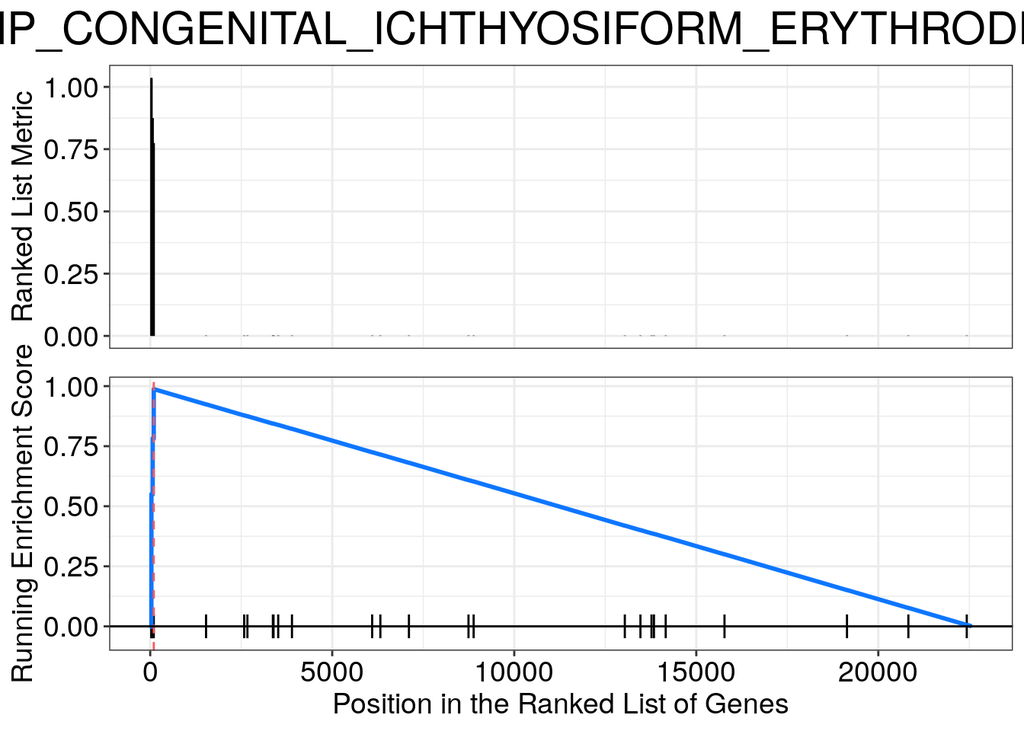

```r
most_positive_nes_plot <- enrichplot::gseaplot(
  gsea_results,
  geneSetID = "HP_CONGENITAL_ICHTHYOSIFORM_ERYTHRODERMA",
  title = "HP_CONGENITAL_ICHTHYOSIFORM_ERYTHRODERMA",
  color.line = "#0d76ff"
)

most_positive_nes_plot
```

The plots returned by `enrichplot::gseaplot` are ggplots, so we can use `ggplot2::ggsave()` to save them to file.

Let’s save to PNG.

```r
ggplot2::ggsave(file.path(plots_dir, "SRP078441_gsea_enrich_positive_plot.png"),
  plot = most_positive_nes_plot
)
```

### 4.5.2 Most Negative NES

Let’s look for the gene set with the most negative NES.

```r
gsea_result_df %>%
  # Use `slice_min()` to return the bottom n observation using `NES` as the ordering
  # variable
  dplyr::slice_min(NES, n = 3)
```

|  | ID | Description | setSize | enrichmentScore | NES | pvalue | p.adjust | qvalues | rank | leading_edge | core_enrichment |
| --- | --- | --- | --- | --- | --- | --- | --- | --- | --- | --- | --- |
| GO_MITOCHONDRIAL_GENE_EXPRESSION | GO_MITOCHONDRIAL_GENE_EXPRESSION | GO_MITOCHONDRIAL_GENE_EXPRESSION | 165 | -0.4200654 | -6.047759 | 5.344381e-26 | 9.352258e-22 | 7.670737e-22 | 9873 | tags=85%, list=44%, signal=48% | MRPL17/MRPL4/RPUSD3/PUS1/TRMT5/MRPS2/TRUB2/MRPS34/MRPL28/MRP…… |
| REACTOME_PROCESSING_OF_CAPPED_INTRON_CONTAINING_PRE_MRNA | REACTOME_PROCESSING_OF_CAPPED_INTRON_CONTAINING_PRE_MRNA | REACTOME_PROCESSING_OF_CAPPED_INTRON_CONTAINING_PRE_MRNA | 239 | -0.3547375 | -6.047380 | 1.004161e-25 | 9.352258e-22 | 7.670737e-22 | 6490 | tags=64%, list=29%, signal=46% | PUF60/NUP210/CDC40/NXT1/DHX16/SRSF11/CSTF2/CSTF2T/POLR2I/HNR…… |
| GO_MITOCHONDRIAL_TRANSLATION | GO_MITOCHONDRIAL_TRANSLATION | GO_MITOCHONDRIAL_TRANSLATION | 135 | -0.4335991 | -5.786998 | 9.954546e-23 | 6.180778e-19 | 5.069484e-19 | 7824 | tags=78%, list=35%, signal=51% | MRPL12/MRPS12/MRPL14/MRPL23/MRPL36/EARS2/GATC/MRPL35/C1QBP/M…… |

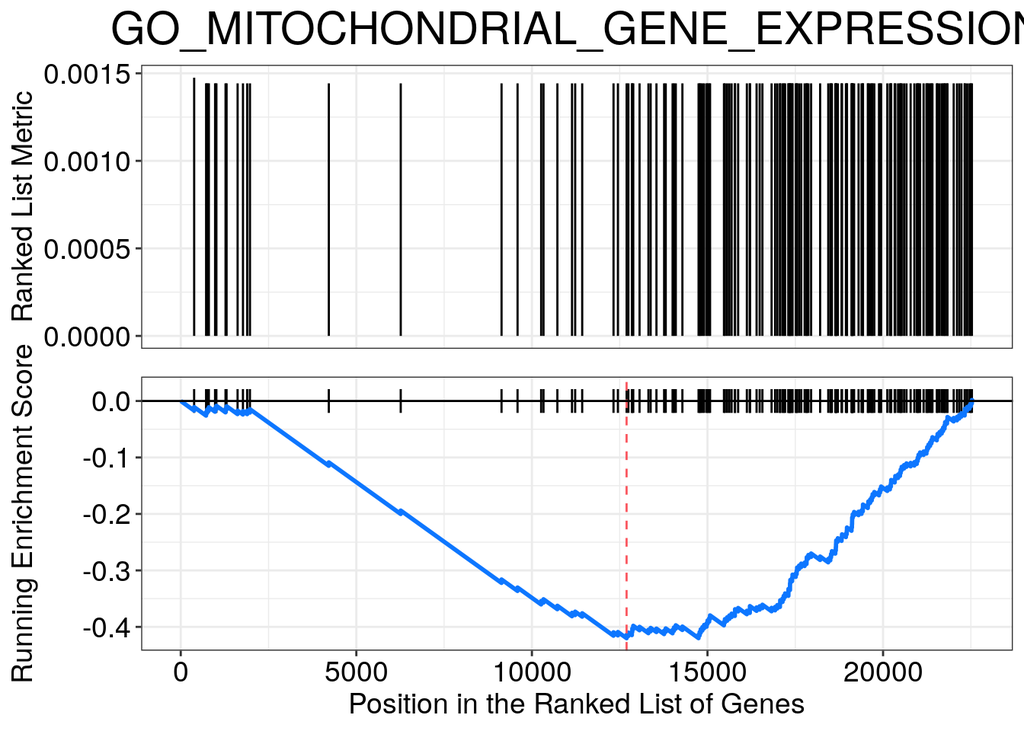

```r
most_negative_nes_plot <- enrichplot::gseaplot(
  gsea_results,
  geneSetID = "GO_MITOCHONDRIAL_GENE_EXPRESSION",
  title = "GO_MITOCHONDRIAL_GENE_EXPRESSION",
  color.line = "#0d76ff"
)

most_negative_nes_plot
```

Let’s save this plot to PNG.

```r
ggplot2::ggsave(file.path(plots_dir, "SRP078441_gsea_enrich_negative_plot.png"),
  plot = most_negative_nes_plot
)
```

## 4.6 Write results to file

```r
readr::write_tsv(
  gsea_result_df,
  file.path(
    results_dir,
    "SRP078441_gsea_results.tsv"
  )
)
```

# 5 Resources for further learning

- [clusterProfiler paper](https://doi.org/10.1089/omi.2011.0118) (Yu *et al.* 2012).
- [clusterProfiler book](https://yulab-smu.github.io/clusterProfiler-book/index.html) (Yu).
- [This handy review](https://doi.org/10.1371/journal.pcbi.1002375) which summarizes the different types of pathway analysis and their limitations (Khatri *et al.* 2012).
- See this [Broad Institute page](https://www.gsea-msigdb.org/gsea/index.jsp) for more on GSEA and MSigDB (Diego and Team).

# 6 Session info

At the end of every analysis, before saving your notebook, we recommend printing out your session info. This helps make your code more reproducible by recording what versions of software and packages you used to run this.

[session information not shown]

# References

Carlson M., 2020 *org.Hs.eg.db: Genome wide annotation for human*. http://bioconductor.org/packages/release/data/annotation/html/org.Hs.eg.db.html

Diego U. S., and B. I. Team, GSEA: Gene set enrichment analysis. https://www.gsea-msigdb.org/gsea/index.jsp

Dolgalev I., 2020 *Msigdbr: MSigDB gene sets for multiple organisms in a tidy data format*. https://cran.r-project.org/web/packages/msigdbr/index.html

Khatri P., M. Sirota, and A. J. Butte, 2012 Ten years of pathway analysis: Current approaches and outstanding challenges. PLOS Computational Biology 8: e1002375. https://doi.org/10.1371/journal.pcbi.1002375

Korotkevich G., V. Sukhov, and A. Sergushichev, 2019 Fast gene set enrichment analysis. bioRxiv. https://doi.org/10.1101/060012

Liberzon A., C. Birger, H. Thorvaldsdóttir, M. Ghandi, and J. P. Mesirov *et al.*, 2015 The molecular signatures database hallmark gene set collection. Cell Systems 1. https://doi.org/10.1016/j.cels.2015.12.004

Love M. I., W. Huber, and S. Anders, 2014 Moderated estimation of fold change and dispersion for RNA-Seq data with DESeq2. Genome Biology 15. https://doi.org/10.1186/s13059-014-0550-8

Micol J. B., A. Pastore, D. Inoue, N. Duployez, and E. Kim *et al.*, 2017 ASXL2 is essential for haematopoiesis and acts as a haploinsufficient tumour suppressor in leukemia. Nature Communications 8: 15429. https://doi.org/10.1038/ncomms15429

Subramanian A., P. Tamayo, V. K. Mootha, S. Mukherjee, and B. L. Ebert *et al.*, 2005 Gene set enrichment analysis: A knowledge-based approach for interpreting genome-wide expression profiles. Proceedings of the National Academy of Sciences 102: 15545–15550. https://doi.org/10.1073/pnas.0506580102

Yu G., L.-G. Wang, Y. Han, and Q.-Y. He, 2012 clusterProfiler: An R package for comparing biological themes among gene clusters. OMICS: A Journal of Integrative Biology 16: 284–287. https://doi.org/10.1089/omi.2011.0118

Yu G., clusterProfiler: Universal enrichment tool for functional and comparative study. http://yulab-smu.top/clusterProfiler-book/index.html

- [Give us feedback](https://share.hsforms.com/1pQ8pPB70TuG37sVjr-KtXA336z0)
- [GitHub](https://github.com/AlexsLemonade/refinebio-examples)
- refine.bio